# Login in, scraping and hidden fields

Jorge Cimentada

2018-04-05

Lightning post. Earlier today I was trying to scrape the emails from all the PhD candidates in my program and I had to log in to out ‘Aula Global’. I did so using `httr` but something was off: I introduced both my username and password but the website did not log in. Apparently, when loging in through `POST`, there’s sometimes hidden fields that you need to fill out! I would’ve never though about this. Below is my case study, excluding my credentials

First thing we have to do is identify the `POST` method and the inputs to the request. Using Google Chrome, go to the website https://sso.upf.edu/CAS/index.php/login?service=https%3A%2F%2Faulaglobal.upf.edu%2Flogin%2Findex.php -> Settings -> More tools -> Developer tools. Here we have the complete html of the website.

1. We identify the POST method and the URL

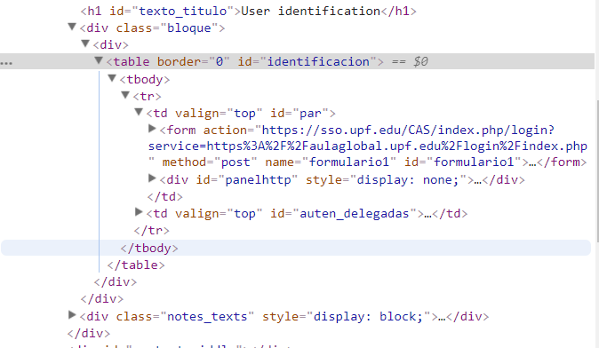

It’s the branch with `form` that has `method='post'`.

2. Open the `POST` branch and find all fields. First are the two ‘hidden’ fields.

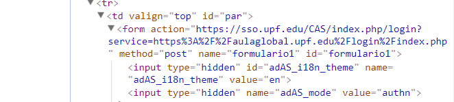

Below the `form` tag, we see two `input` tags set to hidden, there they are! Even though we want to login, we also have to provide the two hidden fields. Take not of both their `name` and `value` tags.

3. Dive deeper down the branch and find other fields. In our case, username and password.

For username:

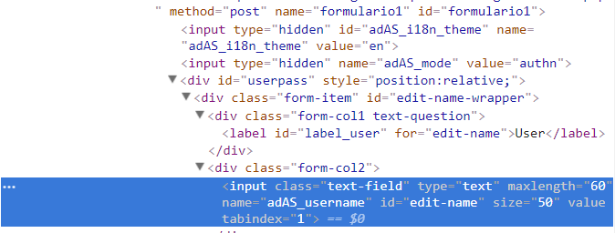

For password:

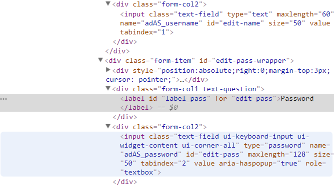

4. Writen down the field names with the correspoding values.

```r
all_fields <-
  list(
    adAS_username = "private",
    adAS_password = "private",
    adAS_i18n_theme = 'en',
    adAS_mode = 'authn'
  )
```

5. Load our packages and our URL’s

```r
library(tidyverse)
library(httr)
library(xml2)

login <- "https://sso.upf.edu/CAS/index.php/login?service=https%3A%2F%2Faulaglobal.upf.edu%2Flogin%2Findex.php"
website <- "https://aulaglobal.upf.edu/user/index.php?page=0&perpage=5000&mode=1&accesssince=0&search&roleid=5&contextid=185837&id=9829"
```

3. Login using all of our fields.

```r
upf <- handle("https://aulaglobal.upf.edu")

access <- POST(login,
               body = all_fields,
               handle = upf)
```

Note how I set the `handle`. If the website you want to visit and the website that hosts the login information have the same root of the URL (`aulaglobal.upf.edu` for example), then you can avoid using `handle` (it’s done behind the scenes). In my case, I set the `handle` to the same root URL of the website I WANT to visit after I log in (because they have different root URL’s). This way the cookies and login information from the login are preserved through out the session.

4. Request the information from the website you’re interested

```r
emails <- GET(website, handle = upf)
```

5. Scrape away!

```r
all_emails <-
  read_html(emails) %>%
  xml_ns_strip() %>%
  xml_find_all("//table//a") %>%
  as_list() %>%
  unlist() %>%
  str_subset(".+@upf.edu$")
```

Unfortunately you won’t be able to reproduce this script because you don’t have a log information unless you belong to the same PhD program as I do. However, I hope you find the hidden fields explanation useful, I’m sure I will come back to this in the near future for reference!